# How to use the line finder utility

This tool finds lines and extrema in the internally calibrated mean spectra. It uses an approach described in Weiler, M. et al. 2023, A&A 671, A52.

## Find extrema in the internally calibrated mean spectra

This tool provides the list of extrema in the internally calibrated mean spectra. No evaluation of spectra in both sampled and continuous forms is performed.

```python
# Import the tool
from gaiaxpy import find_fast
```

### Input types

The available input types are: a pandas DataFrame, an ADQL query, a list of source IDs, and a path to a file with XP CONTINUOUS RAW data (`csv`, `ecsv`, `fits`, or `xml`).

#### Passing a DataFrame

```python
import pandas as pd

f = '/path/to/XP_CONTINUOUS_RAW.csv'
df = pd.read_csv(f)

extrema_pwl = find_fast(df)
extrema_pwl.head()
```

```
Reading input DataFrame... Done!
```

```
                                                                                                                                                                                                                               0/2 [00:00<?, ?spec/s]
```

```
Done! Output saved to path: ./output_lines.csv
```

|  | source_id | xp | extrema |
| --- | --- | --- | --- |
| 0 | 5853498713190525696 | BP | 14.874711 |
| 1 | 5853498713190525696 | BP | 16.885261 |
| 2 | 5853498713190525696 | BP | 17.522690 |
| 3 | 5853498713190525696 | BP | 31.734373 |
| 4 | 5853498713190525696 | BP | 31.944037 |

#### Running a query

```python
query_input = "select TOP 2 source_id from gaiadr3.gaia_source where has_xp_continuous = 'True'"

extrema_pwl = find_fast(query_input)
extrema_pwl.head()
```

```
INFO: Query finished. [astroquery.utils.tap.core]
Running query... Done!
```

```
                                                                                                                                                                                                                               0/2 [00:00<?, ?spec/s]
```

```
Done! Output saved to path: ./output_lines.csv
```

|  | source_id | xp | extrema |
| --- | --- | --- | --- |
| 0 | 488289544781895936 | BP | 15.714108 |
| 1 | 488289544781895936 | BP | 34.459567 |
| 2 | 488289544781895936 | BP | 34.594935 |
| 3 | 488289544781895936 | BP | 36.994297 |
| 4 | 488289544781895936 | BP | 38.556855 |

#### Passing a list

A list of sourceIds can be passed to the fastfinder as the first argument. The converter will then query the Archive for these objects.

```python
sources_list = ['5853498713190525696', 5762406957886626816] # The sourceIds can be string or long.

extrema_pwl = find_fast(sources_list)
extrema_pwl.head()
```

```
Running query... Done!
```

```
                                                                                                                                                                                                                               0/2 [00:00<?, ?spec/s]
```

```
Done! Output saved to path: ./output_lines.csv
```

|  | source_id | xp | extrema |
| --- | --- | --- | --- |
| 0 | 5853498713190525696 | BP | 14.874711 |
| 1 | 5853498713190525696 | BP | 16.885261 |
| 2 | 5853498713190525696 | BP | 17.522690 |
| 3 | 5853498713190525696 | BP | 31.734373 |
| 4 | 5853498713190525696 | BP | 31.944037 |

#### Path to a file

```python
f = '/path/to/XP_CONTINUOUS_RAW.fits'

extrema_pwl = find_fast(f)
extrema_pwl.head() # Only the first few rows of the output are displayed when head() is used.
```

```
Reading input file... Done!
```

```
                                                                                                                                                                                                                               0/2 [00:00<?, ?spec/s]
```

```
Done! Output saved to path: ./output_lines.fits
```

|  | source_id | xp | extrema |
| --- | --- | --- | --- |
| 0 | 5853498713190525696 | BP | 14.874711 |
| 1 | 5853498713190525696 | BP | 16.885261 |
| 2 | 5853498713190525696 | BP | 17.522690 |
| 3 | 5853498713190525696 | BP | 31.734373 |
| 4 | 5853498713190525696 | BP | 31.944037 |

### The fast finder output:

The fast finder returns all found extrema as a pandas DataFrame. The DataFrame contains pseudowavelengths for extrema in BP and RP for each source, respectively.

## Find extrema (and their properties) in the internally calibrated mean spectra

This tool looks for all extrema in the internally calibrated mean spectra. It also converts internally calibrated mean spectra from the continuous representation to an externally calibrated sampled form. The converted spectrum is used to provide basic properties of detected extrema.

```python
# Import the tool
from gaiaxpy import find_extrema
```

### Input types

The available input types are: a pandas DataFrame, an ADQL query, a list of sourceIds, and a path to a file with XP CONTINUOUS RAW data (csv, ecsv, fits, or xml).

#### Passing a DataFrame

```python
import pandas as pd

f = '/path/to/XP_CONTINUOUS_RAW.csv'
df = pd.read_csv(f) # The values in the DataFrame can be edited if the user wishes to do so.

extrema = find_extrema(df)
extrema.head()
```

```
Preparing required internal data...
```

```
                                                                                                                                                                                                                               0/2 [00:00<?, ?spec/s]
```

```
Done! Output saved to path: ./output_lines.csv
```

|  | source_id | line_name | wavelength_nm | line_flux | depth | width | significance | sig_pwl |
| --- | --- | --- | --- | --- | --- | --- | --- | --- |
| 0 | 5853498713190525696 | bp_330 | 330.020145 | 6.956654e-16 | 5.180523e-18 | 3.970387 | 0.042459 | 8.510702 |
| 1 | 5853498713190525696 | bp_334 | 334.593994 | 4.164433e-16 | -1.505134e-17 | 3.816551 | 0.185722 | 4.731364 |
| 2 | 5853498713190525696 | bp_337 | 337.632124 | 2.309730e-16 | -1.001079e-16 | 3.614516 | 1.859752 | 3.284514 |
| 3 | 5853498713190525696 | bp_341 | 341.739965 | 2.065532e-16 | -2.151889e-17 | 3.701070 | 0.602507 | 3.552140 |
| 4 | 5853498713190525696 | bp_344 | 344.993479 | 1.072451e-16 | -1.218512e-16 | 3.931419 | 3.756464 | 3.915424 |

#### Running a query

```python
query_input = "select TOP 2 source_id from gaiadr3.gaia_source where has_xp_continuous = 'True'"

extrema = find_extrema(query_input)
extrema.head()
```

```
INFO: Query finished. [astroquery.utils.tap.core]
Preparing required internal data...
```

```
                                                                                                                                                                                                                               0/2 [00:00<?, ?spec/s]
```

```
Done! Output saved to path: ./output_lines.csv
```

|  | source_id | line_name | wavelength_nm | line_flux | depth | width | significance | sig_pwl |
| --- | --- | --- | --- | --- | --- | --- | --- | --- |
| 0 | 488289544781895936 | bp_333 | 333.993091 | -3.375660e-18 | 1.406177e-18 | 5.592031 | 0.571797 | 1.328987 |
| 1 | 488289544781895936 | bp_340 | 340.467525 | 1.582020e-18 | 3.987157e-18 | 7.154992 | 3.665364 | 2.238799 |
| 2 | 488289544781895936 | bp_348 | 348.374722 | -1.012049e-18 | -1.692863e-18 | 7.203026 | 1.881983 | 2.434976 |
| 3 | 488289544781895936 | bp_363 | 363.364787 | 1.090649e-18 | 1.395584e-18 | 6.722927 | 1.704171 | 2.134727 |
| 4 | 488289544781895936 | bp_370 | 370.041668 | -1.289301e-18 | -2.375571e-18 | 7.546684 | 2.635407 | 3.594792 |

#### Passing a list

A list of sourceIds can be passed to the extremafinder as the first argument. The converter will then query the Archive for these objects.

```python
sources_list = ['5853498713190525696', 5762406957886626816] # The sourceIds can be string or long.

extrema = find_extrema(sources_list)
extrema.head()
```

```
Preparing required internal data...
```

```
                                                                                                                                                                                                                               0/2 [00:00<?, ?spec/s]
```

```
Done! Output saved to path: ./output_lines.csv
```

|  | source_id | line_name | wavelength_nm | line_flux | depth | width | significance | sig_pwl |
| --- | --- | --- | --- | --- | --- | --- | --- | --- |
| 0 | 5853498713190525696 | bp_330 | 330.020145 | 6.956654e-16 | 5.180523e-18 | 3.970387 | 0.042459 | 8.510702 |
| 1 | 5853498713190525696 | bp_334 | 334.593994 | 4.164433e-16 | -1.505134e-17 | 3.816551 | 0.185722 | 4.731364 |
| 2 | 5853498713190525696 | bp_337 | 337.632124 | 2.309730e-16 | -1.001079e-16 | 3.614516 | 1.859752 | 3.284514 |
| 3 | 5853498713190525696 | bp_341 | 341.739965 | 2.065532e-16 | -2.151889e-17 | 3.701070 | 0.602507 | 3.552140 |
| 4 | 5853498713190525696 | bp_344 | 344.993479 | 1.072451e-16 | -1.218512e-16 | 3.931419 | 3.756464 | 3.915424 |

#### Path to a file

```python
f = '/path/to/XP_CONTINUOUS_RAW.fits'

extrema = find_extrema(f)
extrema.head()
```

```
Preparing required internal data...
```

```
                                                                                                                                                                                                                               0/2 [00:00<?, ?spec/s]
```

```
Done! Output saved to path: ./output_lines.fits
```

|  | source_id | line_name | wavelength_nm | line_flux | depth | width | significance | sig_pwl |
| --- | --- | --- | --- | --- | --- | --- | --- | --- |
| 0 | 5853498713190525696 | bp_330 | 330.020145 | 6.956654e-16 | 5.180523e-18 | 3.970387 | 0.042459 | 8.510702 |
| 1 | 5853498713190525696 | bp_334 | 334.593994 | 4.164433e-16 | -1.505134e-17 | 3.816551 | 0.185722 | 4.731364 |
| 2 | 5853498713190525696 | bp_337 | 337.632124 | 2.309730e-16 | -1.001079e-16 | 3.614516 | 1.859752 | 3.284514 |
| 3 | 5853498713190525696 | bp_341 | 341.739965 | 2.065532e-16 | -2.151889e-17 | 3.701070 | 0.602507 | 3.552140 |
| 4 | 5853498713190525696 | bp_344 | 344.993479 | 1.072451e-16 | -1.218512e-16 | 3.931419 | 3.756464 | 3.915424 |

### The extremafinder output:

All found extrema and their properties are returned as a pandas DataFrame. For each detected line following properties are provided:

- line_name,
- wavelength [nm]: calculated from pseudo-wavelength using the GaiaXPy dispersion function,
- flux [W/nm/m^2]: value of flux at the wavelength corresponding to the extremum at pseudo-wavelength,
- depth [W/nm/m^2]: difference between the line flux and the flux in estimated continuum,
- width [nm]: estimated by the distance between the closest inflection points,
- significance: the ratio between the line depth and the flux error at the extremum in the externally calibrated spectrum,
- sig_pwl: the ratio between the line depth and the flux error at the extremum in the internally calibrated spectrum.

## Find lines (and their properties) from a provided list

### Lines in stellar spectra

By defauft this tool provides a short list of lines (H_alpha, H_beta, HeI).

```python
# Import the tool
from gaiaxpy import find_lines
```

### Input types

The available input types are: a pandas DataFrame, an ADQL query, a list of sourceIds, and a path to a file with XP CONTINUOUS RAW data (csv, ecsv, fits, or xml).

#### Passing a DataFrame

```python
import pandas as pd

f = '/path/to/XP_CONTINUOUS_RAW.csv'
df = pd.read_csv(f)

lines = find_lines(df)
lines
```

```
Preparing required internal data...
```

```
                                                                                                                                                                                                                               0/2 [00:00<?, ?spec/s]
```

```
Done! Output saved to path: ./output_lines.csv
```

|  | source_id | line_name | wavelength_nm | line_flux | depth | width | significance | sig_pwl |
| --- | --- | --- | --- | --- | --- | --- | --- | --- |
| 0 | 5853498713190525696 | He I_2 | 586.310487 | 1.236627e-15 | -5.690724e-17 | 22.490756 | 4.207830 | 5.056023 |
| 1 | 5853498713190525696 | H_alpha | 655.968059 | 4.178223e-15 | 1.856800e-15 | 14.492901 | 29.068717 | 58.355642 |
| 2 | 5853498713190525696 | He I_3 | 704.156775 | 4.863446e-15 | 1.879177e-15 | 14.016893 | 18.544342 | 15.292537 |
| 3 | 5762406957886626816 | H_beta | 484.420302 | 2.409925e-16 | -7.701987e-17 | 19.829839 | 30.636190 | 52.906350 |
| 4 | 5762406957886626816 | H_alpha | 655.954918 | 8.142886e-17 | -2.154309e-17 | 14.190875 | 19.575013 | 34.208743 |
| 5 | 5762406957886626816 | He I_3 | 707.165598 | 7.877543e-17 | 1.357762e-18 | 11.660292 | 1.981938 | 2.918542 |

#### Passing a list

A list of sourceIds can be passed to the extremafinder as the first argument. The converter will then query the Archive for these objects.

```python
sources_list = ['5853498713190525696', 5762406957886626816] # The source IDs can be either strings or long integers.

lines = find_lines(sources_list)
lines
```

```
Preparing required internal data...
```

```
                                                                                                                                                                                                                               0/2 [00:00<?, ?spec/s]
```

```
Done! Output saved to path: ./output_lines.csv
```

|  | source_id | line_name | wavelength_nm | line_flux | depth | width | significance | sig_pwl |
| --- | --- | --- | --- | --- | --- | --- | --- | --- |
| 0 | 5853498713190525696 | He I_2 | 586.310487 | 1.236627e-15 | -5.690724e-17 | 22.490756 | 4.207830 | 5.056023 |
| 1 | 5853498713190525696 | H_alpha | 655.968059 | 4.178223e-15 | 1.856800e-15 | 14.492901 | 29.068717 | 58.355642 |
| 2 | 5853498713190525696 | He I_3 | 704.156775 | 4.863446e-15 | 1.879177e-15 | 14.016893 | 18.544342 | 15.292537 |
| 3 | 5762406957886626816 | H_beta | 484.420302 | 2.409925e-16 | -7.701987e-17 | 19.829839 | 30.636190 | 52.906350 |
| 4 | 5762406957886626816 | H_alpha | 655.954918 | 8.142886e-17 | -2.154309e-17 | 14.190875 | 19.575013 | 34.208743 |
| 5 | 5762406957886626816 | He I_3 | 707.165598 | 7.877543e-17 | 1.357762e-18 | 11.660292 | 1.981938 | 2.918542 |

#### Path to a file

```python
f = '/path/to/XP_CONTINUOUS_RAW.fits'

lines = find_lines(f)
lines
```

```
Preparing required internal data...
```

```
                                                                                                                                                                                                                               0/2 [00:00<?, ?spec/s]
```

```
Done! Output saved to path: ./output_lines.fits
```

|  | source_id | line_name | wavelength_nm | line_flux | depth | width | significance | sig_pwl |
| --- | --- | --- | --- | --- | --- | --- | --- | --- |
| 0 | 5853498713190525696 | He I_2 | 586.310487 | 1.236627e-15 | -5.690724e-17 | 22.490756 | 4.207830 | 5.056023 |
| 1 | 5853498713190525696 | H_alpha | 655.968059 | 4.178223e-15 | 1.856800e-15 | 14.492901 | 29.068718 | 58.355641 |
| 2 | 5853498713190525696 | He I_3 | 704.156775 | 4.863446e-15 | 1.879177e-15 | 14.016893 | 18.544343 | 15.292538 |
| 3 | 5762406957886626816 | H_beta | 484.420302 | 2.409925e-16 | -7.701987e-17 | 19.829839 | 30.636189 | 52.906350 |
| 4 | 5762406957886626816 | H_alpha | 655.954918 | 8.142886e-17 | -2.154309e-17 | 14.190875 | 19.575013 | 34.208743 |
| 5 | 5762406957886626816 | He I_3 | 707.165598 | 7.877543e-17 | 1.357762e-18 | 11.660292 | 1.981938 | 2.918542 |

### The linefinder output:

All found lines and their properties are returned as a pandas DataFrame. For each detected line following properties are provided:

- line_name,
- wavelength [nm]: calculated from pseudo-wavelength using the GaiaXPy dispersion function,
- flux [W/nm/m^2]: value of flux at the wavelength corresponding to the extremum at pseudo-wavelength,
- depth [W/nm/m^2]: difference between the line flux and the flux in estimated continuum,
- width [nm]: estimated by the distance between the closest inflection points,
- significance: the ratio between the line depth and the flux error at the extremum in the externally calibrated spectrum,
- sig_pwl: the ratio between the line depth and the flux error at the extremum in the internally calibrated spectrum.

### Lines in QSO spectra

It is possible to change a source type to QSO and provide redshift(s). By defauft this tool provides a short list of lines (H_alpha, H_beta, CIV, CIII], MgII, Ly_alpha).

```python
# A list of sourceIds
sources_list = [858200268935710208, 3937755935439564672]
# A list with redshifts
zets = [(858200268935710208, 0.06107), (3937755935439564672, 2.698)]

lines = find_lines(sources_list, source_type='qso', redshift=zets)
lines
```

```
Preparing required internal data...
```

```
                                                                                                                                                                                                                               0/2 [00:00<?, ?spec/s]
```

```
Done! Output saved to path: ./output_lines.csv
```

|  | source_id | line_name | wavelength_nm | line_flux | depth | width | significance | sig_pwl |
| --- | --- | --- | --- | --- | --- | --- | --- | --- |
| 0 | 858200268935710208 | H_beta | 519.826376 | 3.409607e-17 | 1.465183e-17 | 26.649797 | 13.423813 | 25.802867 |
| 1 | 858200268935710208 | H_alpha | 696.920068 | 6.136522e-17 | 5.011845e-17 | 16.417239 | 38.716931 | 66.964718 |
| 2 | 3937755935439564672 | Ly_alpha | 453.975163 | 2.954658e-18 | 1.917204e-18 | 16.403438 | 5.230892 | 12.308939 |
| 3 | 3937755935439564672 | C IV | 570.721363 | 1.114978e-18 | 5.137242e-19 | 26.334381 | 5.040652 | 6.930669 |
| 4 | 3937755935439564672 | C III] | 710.276640 | 7.914149e-19 | 3.288256e-19 | 11.389798 | 2.849785 | 4.142953 |

## Other options

Additional arguments can be passed to the tools.

These are:

1. truncation
2. user_lines
3. plot_spectra
4. save_plots
5. output_path
6. output_file
7. output_format
8. save_file

### Truncation

The source mean BP/RP spectrum is described as a combination of basis functions. Particularly for faint sources or sources with a low number of observations, it is useful to represent the spectrum using a smaller set of basis functions to avoid higher-order bases fitting the noise in the observed data.

The **truncation** parameter is a boolean which toggles the truncation of the set of bases.

```python
# A list of sourceIds
sources_list = [5853498713190525696, 5762406957886626816]

extrema_pwl_tr = find_fast(sources_list, truncation=True)
extrema_pwl_tr.head()
```

```
Running query... Done!
```

```
                                                                                                                                                                                                                               0/2 [00:00<?, ?spec/s]
```

```
Done! Output saved to path: ./output_lines.csv
```

|  | source_id | xp | extrema |
| --- | --- | --- | --- |
| 0 | 5853498713190525696 | BP | 14.874719 |
| 1 | 5853498713190525696 | BP | 16.885232 |
| 2 | 5853498713190525696 | BP | 17.522827 |
| 3 | 5853498713190525696 | BP | 31.731594 |
| 4 | 5853498713190525696 | BP | 31.946459 |

### User's list of lines

An independent set of lines can be provided in a form of a list or a file. The lines can be provided to the parameter **user_lines**. This option is available for the linefinder tool only.

```python
# A list of sourceIds
sources_list = [5853498713190525696, 5762406957886626816]
# A list with user's lines: wavelengths [nm] and names
new_lines = [(434.0472, 410.1734), ('H_gamma', 'H_delta')]

lines = find_lines(sources_list, user_lines=new_lines)
lines
```

```
Preparing required internal data...
```

```
                                                                                                                                                                                                                               0/2 [00:00<?, ?spec/s]
```

```
Done! Output saved to path: ./output_lines.csv
```

|  | source_id | line_name | wavelength_nm | line_flux | depth | width | significance | sig_pwl |
| --- | --- | --- | --- | --- | --- | --- | --- | --- |
| 0 | 5762406957886626816 | H_gamma | 431.162668 | 3.534201e-16 | -7.068856e-17 | 13.200787 | 12.131214 | 33.215733 |

```python
# Path to file with lines
f = '/path/to/lines_example.txt'

lines = find_lines(sources_list, user_lines=f)
lines
```

```
Preparing required internal data...
```

```
                                                                                                                                                                                                                               0/2 [00:00<?, ?spec/s]
```

```
Done! Output saved to path: ./output_lines.csv
```

|  | source_id | line_name | wavelength_nm | line_flux | depth | width | significance | sig_pwl |
| --- | --- | --- | --- | --- | --- | --- | --- | --- |
| 0 | 5853498713190525696 | H_alpha | 655.968059 | 4.178223e-15 | 1.856800e-15 | 14.492901 | 29.068717 | 58.355642 |
| 1 | 5762406957886626816 | H_beta | 484.420302 | 2.409925e-16 | -7.701987e-17 | 19.829839 | 30.636190 | 52.906350 |
| 2 | 5762406957886626816 | H_alpha | 655.954918 | 8.142886e-17 | -2.154309e-17 | 14.190875 | 19.575013 | 34.208743 |

*Note:* The file should contain two columns separated by spaces: the first for wavelengths [nm] and the second for line names, with no header.

E.g.:

```
656.461 H_alpha
486.268 H_beta
```

### Plotting spectra

It is possible to plot spectra with marked detected extrema or lines by using a boolean parameter **plot_spectra**. This option is available for the linefinder and extremafinder tools only.

```
Preparing required internal data...
```

```
Finding lines:   0%|                                                                                                                                                                                   | 0/1 [00:00<?, ?spec/s]
```

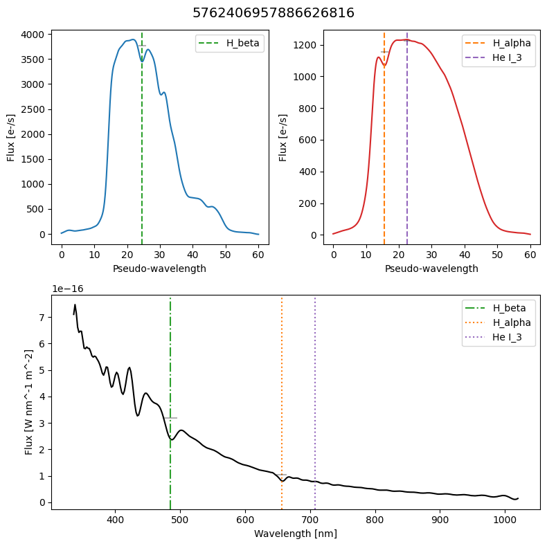

```
                                                                                                                                                                                                                               01<00:00,  1.28s/spec]
```

```
Done! Output saved to path: ./output_lines.csv
```

```python
lines = find_lines([5762406957886626816], plot_spectra=True)
```

The additional boolean parameter **save_plots** is a boolean that tells the program whether to save the plots.

```
Preparing required internal data...
```

```
                                                                                                                                                                                                                               02<00:00,  2.85s/spec]
```

```
Done! Output saved to path: ./output_lines.csv
```

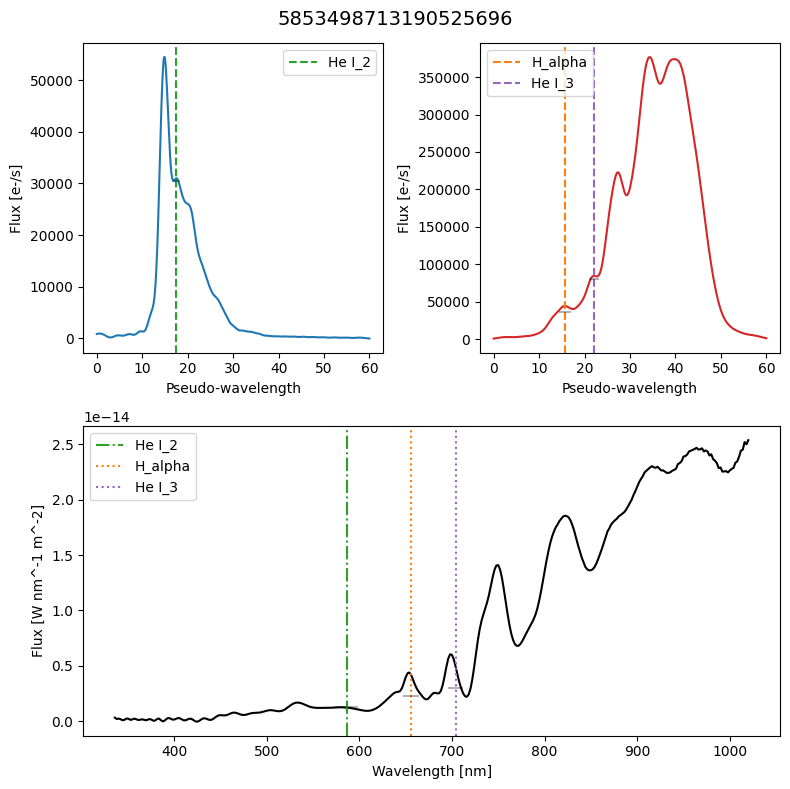

```python
lines = find_lines([5853498713190525696], plot_spectra=True, save_plots=True)
```

### Output_path, output_file, output_format, save_file

Three parameters: **output_path**, **output_file**, and **output_format** define the entire path of the resulting file.

The default output path is the current path. If the given output path does not exist, it will be created.

The default output file name is 'output_lines'.

The default output format is the same as the format of the input file (i.e. if the input file format is 'fits', then by default, the output file will be a FITS file.), or CSV in any other case (DataFrame, ADQL query or list).

```python
lines = find_lines([5853498713190525696], output_path='.', output_file='my_file', output_format='ecsv')
```

```
Preparing required internal data...
```

```
                                                                                                                                                                                                                               0/1 [00:00<?, ?spec/s]
```

```
Done! Output saved to path: ./my_file.ecsv
```

```python
lines = find_lines([5853498713190525696], output_path='.', output_file='my_file', output_format='ecsv', save_file=False)
```

```
Preparing required internal data...
```

```
                                                                                                                                                                                                                               0/1 [00:00<?, ?spec/s]
```